# What Makes a Restaurant Successful in New Orleans

# PART 2: STATISTICS

### Average Yelp Rating (Quality)

We are investigating the overall quality of the restaurants in New Orleans. The average Yelp rating of the New Orleans restaurants is approximately 3.76 stars, showing decent customer satisfaction ratings.

```python
round(float(nolaRestaurants_noZip['stars'].mean()),2)
```

```
3.76
```

### Average Review Count (Popularity)

We are measuring the New Orleans restaurant popularity or visibility. Restaurants receive an average of about 278 reviews.

Some of the more established resaurants are receiving significantly more reviews.

```python
round(float(nolaRestaurants_noZip['review_count'].mean()),2)
```

```
278.21
```

### Correlation between the Ratings and the Volume of Reviews

Looking at whether the New Orleans restaurants that are considered "better" attract more attention. Based on the correlation analysis between the Yelp ratings and the volume of reviews, we are able to determine whether the higher-rated restaurants tend to have a higher customer engagement.

Based on the data, restaurants with higher ratings do tend to have SLIGHTLY more reviews but the overall relationship is very weak (0.1147 = very weak positive correlation). This means that higher-rated restaurants are not a strong predictor of whether a restaurant is popular.

```python
nolaRestaurants_noZip[['stars','review_count']].corr()
```

|  | stars | review_count |
| --- | --- | --- |
| stars | 1.000000 | 0.114694 |
| review_count | 0.114694 | 1.000000 |

### Relationship Between Review Count and Ratings (Scatter Plot)

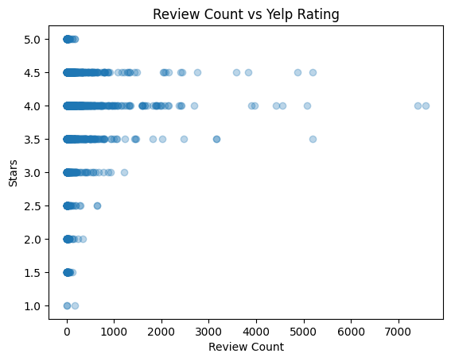

```python
import matplotlib.pyplot as plt
plt.scatter(nolaRestaurants_noZip['review_count'], nolaRestaurants_noZip['stars'], alpha=0.3)
plt.xlabel("Review Count")
plt.ylabel("Stars")
plt.title("Review Count vs Yelp Rating")
plt.show()
```

The correlation coeffecient shows a weak positive relationship. However, the scatter plot gives insight onto what is really going on. As the number of reviews increase, restaurant ratings cluster around approx 4 stars. Restaurants with fewer reviews show more varaibility with high and low ratings. This is an indiciation of "regression to the mean effect", basically indicating that restaurants with more reviews have more stable ratings showing why review count is not the best predictor of restaurant success.

### MOST POPULAR RESTAURANT

Restaurants with the highest review counts are generally considered more popular within New Orleans.

Based on the analysis, Acme Oyster House and Oceana Grill are considered to be some of the most reviewed establishment with over 7000 reviews. Most of the restaurants that take the top ten have ratings between 4.0 and 4.5 stars which could suggest that the popular restaurants tend to maintain high ratings.

However, some very popular restaurants don't always have the highest ratings. Mother's restaurant has a 3.5 star ratings with over 5000 reviews indicating the correlation to be weaker but present.

```python
restaurant_income.sort_values(by='review_count', ascending=False)[['name','stars','review_count']].head(10)
```

|  | name | stars | review_count |
| --- | --- | --- | --- |
| 4736 | Acme Oyster House | 4.0 | 7568 |
| 4679 | Oceana Grill | 4.0 | 7400 |
| 6091 | Ruby Slipper - New Orleans | 4.5 | 5193 |
| 4138 | Mother's Restaurant | 3.5 | 5185 |
| 1288 | Royal House | 4.0 | 5070 |
| 1297 | Commander's Palace | 4.5 | 4876 |
| 200 | Luke | 4.0 | 4554 |
| 4016 | Cochon | 4.0 | 4421 |
| 2648 | Felix's Restaurant & Oyster Bar | 4.0 | 3966 |
| 1734 | Gumbo Shop | 4.0 | 3902 |

### MOST COMMON CUISINES IN NEW ORLEANS

Analyzing the restaurant categories to determine which cuisine style is the most prevalent in New Orleans.

Chinese and Pizza Cuisines take the top rankings as they are more commonly found!

```python
nolaRestaurants_noZip['categories'].value_counts().head(10)
```

| categories | count |
| --- | --- |
| Restaurants, Chinese | 16 |
| Restaurants, Pizza | 9 |
| Restaurants, Cajun/Creole | 8 |
| Cajun/Creole, Restaurants | 7 |
| Seafood, Restaurants | 7 |
| Restaurants, Seafood | 7 |
| American (New), Restaurants | 6 |
| Restaurants, Cajun/Creole, Seafood | 6 |
| Restaurants, Mexican | 6 |
| Chinese, Restaurants | 6 |

**dtype:** int64

### MOST POPULAR RESTAURANT'S CUISINE TYPE

```python
nolaRestaurants_noZip.sort_values(by='review_count', ascending=False)[['name','categories','stars','review_count']].head(10)
```

|  | name | categories | stars | review_count |
| --- | --- | --- | --- | --- |
| 26439 | Acme Oyster House | Live/Raw Food, Seafood, Restaurants, Cajun/Creole | 4.0 | 7568 |
| 26163 | Oceana Grill | Restaurants, Seafood, Cajun/Creole, Breakfast ... | 4.0 | 7400 |
| 34209 | Ruby Slipper - New Orleans | Restaurants, American (Traditional), American ... | 4.5 | 5193 |
| 23267 | Mother's Restaurant | Cajun/Creole, Restaurants, Event Planning & Se... | 3.5 | 5185 |
| 7267 | Royal House | American (New), Restaurants, Sandwiches, Seafo... | 4.0 | 5070 |
| 7346 | Commander's Palace | French, Restaurants, Cocktail Bars, Nightlife,... | 4.5 | 4876 |
| 1030 | Luke | German, Restaurants, Seafood, Cocktail Bars, F... | 4.0 | 4554 |
| 22644 | Cochon | Cajun/Creole, Seafood, Restaurants | 4.0 | 4421 |
| 14949 | Felix's Restaurant & Oyster Bar | Restaurants, Sandwiches, Seafood, Cajun/Creole | 4.0 | 3966 |
| 9850 | Gumbo Shop | Cajun/Creole, Seafood, Restaurants | 4.0 | 3902 |

From inspection of the top 10 restaurants by review count, many of the restaurants fall under seafood-related categories. This suggests that seafood restaurants appear frequently among the most reviewed establishments in the dataset. This observation may indicate that seafood restaurants are popular in this region, although additional analysis would be needed to determine whether seafood restaurants tend to be more successful overall.

SUMMARY: These statistics show a brief overview of the dining lanscape in New Orleans, indicating that the more popular restaurants do maintain a relatively strong rating however it is not based on ratings alone. There are additional factors such as types of cuisine and location that also relate to restaurant success.

Therefore, POPULARITY AND QUALITY ARE NOT THE SAME THING.

# New data EDA

### Average Rating per Neighborhood Income:

We can compare the average ratings restaurants have in different zip code locations based on household income in those areas. We can try grouping out data, but it is hard to see any trends or draw any conclusions this way. We can try a cross tab to compare these 2 variables better.

```python
restaurant_income.groupby("USD")["stars"].mean().sort_index(ascending=False)
```

| USD | stars |
| --- | --- |
| 121228 | 3.904444 |
| 90182 | 3.936196 |
| 80212 | 3.768543 |
| 63750 | 3.803899 |
| 62389 | 3.565217 |
| 61174 | 3.708861 |
| 56431 | 2.857143 |
| 55972 | 3.575000 |
| 53143 | 3.888889 |
| 52306 | 4.052985 |
| 49455 | 3.511538 |
| 45764 | 4.107038 |
| 43493 | 3.645299 |
| 41709 | 3.228155 |
| 40765 | 3.395833 |
| 39333 | 3.898026 |
| 19395 | 3.729263 |

**dtype:** float64

### Cross Tab Rating and Neighborhood Income:

```python
# Creating income group variable
restaurant_income["income_group"] = pd.cut(
    restaurant_income["USD"],
    bins=[0, 50000, 80000, 200000],
    labels=["Low", "Middle", "High"])


#creare rating group variable
restaurant_income["rating_group"] = pd.cut(
    restaurant_income["stars"],
    bins=[0, 3, 4, 5],
    labels=["Low (≤3)", "Medium (3–4)", "High (4–5)"]
)
#create the cross tab
rating_crosstab= pd.crosstab(restaurant_income['income_group'], restaurant_income['rating_group'])
display(rating_crosstab)

rating_crosstab2= pd.crosstab(restaurant_income['income_group'], restaurant_income['rating_group'], normalize=True, margins=True)
display(rating_crosstab2)
```

| rating_group income_group | Low (≤3) | Medium (3–4) | High (4–5) |
| --- | --- | --- | --- |
| Low | 337 | 535 | 477 |
| Middle | 401 | 804 | 784 |
| High | 547 | 1144 | 859 |

| rating_group income_group | Low (≤3) | Medium (3–4) | High (4–5) | All |
| --- | --- | --- | --- | --- |
| Low | 0.057235 | 0.090863 | 0.081012 | 0.229110 |
| Middle | 0.068105 | 0.136549 | 0.133152 | 0.337806 |
| High | 0.092901 | 0.194293 | 0.145890 | 0.433084 |
| All | 0.218240 | 0.421705 | 0.360054 | 1.000000 |

Now with this cross tab we can see many different trends:

Wealthier areas drive the data: Nearly 43% of all restaurant ratings come from high-income zip codes. In contrast, low-income areas contribute only about 23% of the feedback, suggesting much higher restaurant activity or reporting in affluent neighborhoods.

A "High-Income, Medium-Rating" majority: The most frequent scenario in the entire dataset is restaurants in high-income areas receiving a medium rating.

Universal Satisfaction Trend: Regardless of income, the "Medium (3–4)" rating is consistently the most common. People across all zip codes are more likely to have an "average to good" experience than an "excellent" or "poor" one.

Low-Income: While low-income areas have the fewest total ratings, they have the highest proportion of "Low" ratings relative to their own total. About 25% (337/1349) of ratings in low-income areas are low, compared to only 21% (547/2550)in high-income areas.

Let's see if we get similar results ith review counts and neigborhood income.

### Cross Tab Review Count and Neighborhood Income:

```python
restaurant_income["review_group"] = pd.cut(
    restaurant_income["review_count"],
    bins=[0, 20, 100, 1000, float('inf')],
    labels=["Few (0-20)", "Moderate (21-100)", "Many (101-1000)", "Viral(1000+)"])

review_crosstab = pd.crosstab(restaurant_income['income_group'], restaurant_income['review_group'])
display(review_crosstab)

review_crosstab2 = pd.crosstab(restaurant_income['income_group'], restaurant_income['review_group'],normalize=True, margins=True)
display(review_crosstab2)
```

| review_group income_group | Few (0-20) | Moderate (21-100) | Many (101-1000) | Viral(1000+) |
| --- | --- | --- | --- | --- |
| Low | 723 | 437 | 180 | 9 |
| Middle | 982 | 627 | 355 | 25 |
| High | 1110 | 839 | 549 | 52 |

| review_group income_group | Few (0-20) | Moderate (21-100) | Many (101-1000) | Viral(1000+) | All |
| --- | --- | --- | --- | --- | --- |
| Low | 0.122792 | 0.074219 | 0.030571 | 0.001529 | 0.229110 |
| Middle | 0.166780 | 0.106488 | 0.060292 | 0.004246 | 0.337806 |
| High | 0.188519 | 0.142493 | 0.093240 | 0.008832 | 0.433084 |
| All | 0.478091 | 0.323200 | 0.184103 | 0.014606 | 1.000000 |

This cross-tabulation focuses on the volume of reviews (from "Few" to "Viral") versus household income. Here is what the data tells us:

Review Volume is Tied to Wealth: High-income zip codes are much more likely to host "Viral" or "Many" reviewed restaurants. In fact, restaurants with over 1,000 reviews (Viral) are nearly 6 times more common in high-income areas (52) than in low-income areas (9).

The "Few" Category Dominates: Across every income bracket, the most common type of restaurant is one with "Few (0–20)" reviews, accounting for nearly 48% of the entire dataset. This suggests a market filled with small or new establishments regardless of the neighborhood's wealth.

Concentrated Popularity: "Viral" restaurants are extremely rare everywhere, making up only 1.4% of your total data. However, the vast majority of those rare viral spots (60% of them) are located in high-income zip codes.

We can conlcude that popularity (measured by review count) are heavily concentrated in wealthier areas, while low-income areas are mostly characterized by restaurants with very few reviews.

To have a better visualization of this data, we can plot these results using a heatmap.

### Heat Maps

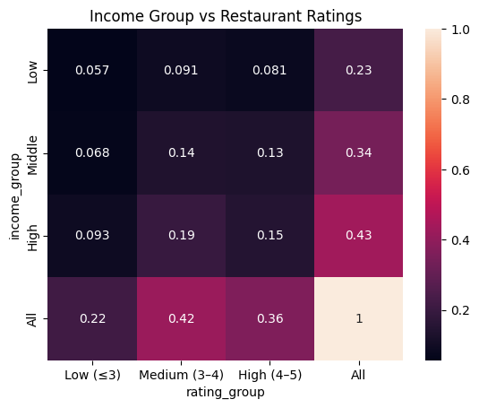

[figure not shown]

```python
import seaborn as sns
import matplotlib.pyplot as plt

sns.heatmap(rating_crosstab2, annot=True)
plt.title("Income Group vs Restaurant Ratings")
plt.show()

sns.heatmap(review_crosstab2, annot=True)
plt.title("Income Group vs Restaurant Ratings")
plt.show()
```

Now we ca clearly see different trends.Heat maps are better because they use color gradients to reveal trends and outliers instantly. By simplifying data into a visual landscape,we can grasp the big picture and draw the same conclusions we got from the cross tabs.

# PART 3: GRAPH

The graph below represents the distribution of the Yelp Ratings that show majority of New Orleans restaurants fall between 4-5 stars, showing a general positive customer satisfaction with cuisine in the city.

[figure not shown]

```python
import matplotlib.pyplot as plt

plt.figure(figsize=(8,5))

plt.hist(nolaRestaurants_noZip['stars'],
         bins=[1,1.5,2,2.5,3,3.5,4,4.5,5],
         color="#2E86AB",
         edgecolor="black")

plt.title("Distribution of Yelp Ratings in New Orleans", fontsize=14)
plt.xlabel("Yelp Rating", fontsize=12)
plt.ylabel("Number of Restaurants", fontsize=12)

plt.grid(axis='y', linestyle='--', alpha=0.6)

plt.show()
```

Another interesting visualization could be a bar graph showing the relationship between review counts and cuisine type.

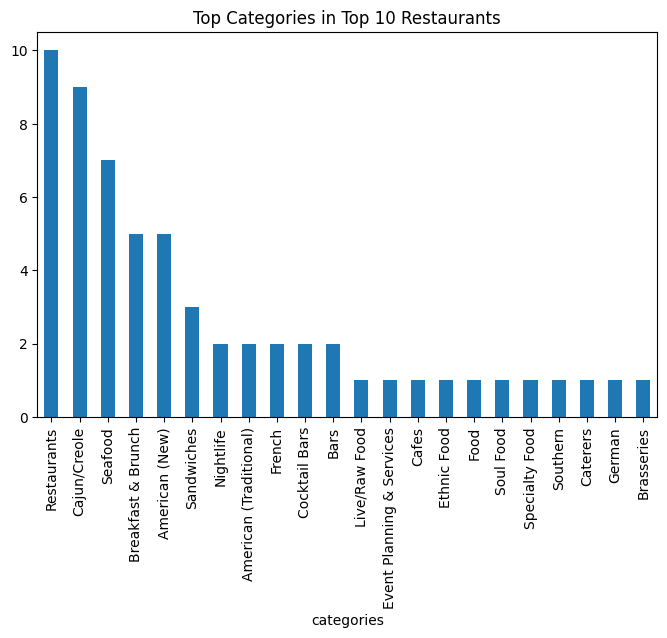

```python
#We want the top 10
top10 = nolaRestaurants_noZip.sort_values(by='review_count', ascending=False).head(10)
category_counts = top10['categories'].str.split(', ').explode().value_counts()
category_counts.plot(kind='bar', figsize=(8,5), title="Top Categories in Top 10 Restaurants")
```

Restaurants is a category for all of these so that is why it's the tallest bar, but the second tallest bar is Cajun/Creole. This observation may indicate that Caujun/Creole restaurants are popular in this region.

# PART 4: Models

# **Model 1: Linear Regression (Predicting Restaurant Ratings)**

RESEARCH QUESTION: To what extent does the customer engagement, location, and neighborhood income predict overall restaurant success in New Orleans, measured by Yelp star ratings.

MODEL TYPE: Linear Regression (continuous prediction)

INDEPENDENT VARIABLES (X):

- review_count (customer engagement)
- postal_code (location, zipcode)
- income (median income of zipcode)

DEPENDENT VARIABLE (Y):

- stars (Yelp rating)

METHODOLOGY: We trained a linear regression model using a train-test method to predict restaurant ratings. The model performance is evaluated via:

- R^2 (coeffecient of determination): measure explanatory power
- Mean Sqared Error (MSE) to measure prediction error

```python
import pandas as pd
from sklearn.model_selection import train_test_split
from sklearn.linear_model import LinearRegression
from sklearn.metrics import r2_score, mean_squared_error
import matplotlib.pyplot as plt

#cleaning

# Fill missing income values
restaurant_income['USD'] = restaurant_income['USD'].fillna(restaurant_income['USD'].mean())

#encoding zipcodes

zip_dummies = pd.get_dummies(restaurant_income['postal_code'], drop_first=True)

#define features and target

X = pd.concat([
    restaurant_income[['review_count', 'USD']],
    zip_dummies
], axis=1)

y = restaurant_income['stars']

#train and test

X_train, X_test, y_train, y_test = train_test_split(
    X, y, test_size=0.2, random_state=42
)

#train

model = LinearRegression()
model.fit(X_train, y_train)

#evaluate model

y_pred = model.predict(X_test)

print("R^2 Score:", r2_score(y_test, y_pred))
print("Mean Squared Error:", mean_squared_error(y_test, y_pred))
```

```
R^2 Score: 0.004010414685158503
Mean Squared Error: 0.726266151029985
```

The linear regression model generated an R^2 value of approximately 0.004 which shows the model explains almost none of the variation in ratings. Our variables explain about 0.4% of why the ratings differ. Therefore, customer engagement (review count), neighborhood income, and zipcode and not great predictors of restaurant ratings in New Orleans.

The results generated from this model is consistent with the earlier analysis which all showed very weak correlations between ratings and income, as well as review count. Thus restaurant ratings are likely influenced by other factors (perhaps cuisine type, service quality, or customer preferences)

**Model 2: Decision Tree Classification Regression (Classification to predict high-rated restaurants)**

RESEARCH QUESTION: To what extent does customer behavior (review levels) and neighborhood income groups predict whether a restaurant is highly rated in New Orleans?

MODEL TYPE: Decision Tree Classifier (classification)

INDEPENDENT VARIABLES (X):

income_group (Low, Middle, High - based on median household income) review_group (Few, Moderate, Many, Viral - based on no. of reviews)

DEPENDENT VARIABLE (Y): high_rating (binary variable: 1 if stars is greater than or equal to 4.0, 0 otherwise)

METHODOLOGY: We made a decision tree classification model that uses training and testing to predict whether a model is highly rated. We chose this model because it works well with categorical patterns. Rather than raw numerical variables, we grouped variables that were derived from earlier analysis. These groupings capture patterns in customer behavior and characteristics of different neighborhoods.

This allows us to understand how combinations of income levels, and review activity can be correlated with restaurant success. The model was evaluated with accuracy, precision and recall to assess performance, F1 score to balance precision and recall, and confusion matrix to visualize the correct and incorrect classifications.

```python
import pandas as pd
from sklearn.model_selection import train_test_split
from sklearn.tree import DecisionTreeClassifier
from sklearn.metrics import accuracy_score, classification_report, confusion_matrix



# Convert ratings into binary classification
# 1 = high-rated (≥ 4 stars), 0 = not high-rated
restaurant_income['high_rating'] = (restaurant_income['stars'] >= 4.0).astype(int)


# These were created earlier
# income_group (Low, Middle, High)
# review_group (Few, Moderate, Many, Viral)

# Convert categorical groups into numerical format using one-hot encoding
income_dummies = pd.get_dummies(restaurant_income['income_group'], drop_first=True)
review_dummies = pd.get_dummies(restaurant_income['review_group'], drop_first=True)

# Combine features
X = pd.concat([income_dummies, review_dummies], axis=1)

# Target variable
y = restaurant_income['high_rating']

# train/test

# Split data into training and testing sets (80/20 split)
X_train, X_test, y_train, y_test = train_test_split(
    X, y, test_size=0.2, random_state=42
)

# train with class balance to ensure model pays attention to both classes
model = DecisionTreeClassifier(max_depth=4, class_weight='balanced', random_state=42)
model.fit(X_train, y_train)

# make predictions

y_pred = model.predict(X_test)

# evaluate model

# accuracy: overall correctness
print("Accuracy:", accuracy_score(y_test, y_pred))

# classification report: precision, recall, F1-score
print("\nClassification Report:\n", classification_report(y_test, y_pred))

# confusion matrix: breakdown of correct/incorrect predictions
print("\nConfusion Matrix:\n", confusion_matrix(y_test, y_pred))
```

```
Accuracy: 0.5271646859083192

Classification Report:
               precision    recall  f1-score   support

           0       0.44      0.57      0.50       478
           1       0.63      0.50      0.55       700

    accuracy                           0.53      1178
   macro avg       0.53      0.53      0.53      1178
weighted avg       0.55      0.53      0.53      1178


Confusion Matrix:
 [[274 204]
 [353 347]]
```

Based on the decision tree, we obtained an accuracy of approx. 0.53 which is slightly better than randomely predicting whether or not a restaurant is highly rated.

This model is able to predict both high-rated and not high-rated restaurants as shown in the confusion matrix which means that it correctly identifies each clas with okay recall and precision scores for both categories.

Yet, overall performance is relatively weak since the model makes a good bit of misclassifications in distinguishing. This suggests that the features of income group and review group don't necessarily differentiate proper restaurant success.

This is a finding that is consistent with earlier analysis which also showed a weaker relationship with ratings, income, and customer engagement. Thus, restaurant success in NOLA is mostly influenced by other factors that aren't found in this dataset.

### Model 3: Linear regression with categories and wifi availablity

RESEARCH QUESTION: To what extent does the customer engagement, location, neighborhood income, cuisine type, and wifi availability predict overall restaurant success in New Orleans, measured by Yelp star ratings.

MODEL TYPE: Linear Regression (continuous prediction)

INDEPENDENT VARIABLES (X):

review_count (customer engagement) postal_code (location, zipcode) income (median income of zipcode) cuisine type wifi (has wifi or not)

DEPENDENT VARIABLE (Y):

stars (Yelp rating) METHODOLOGY: We trained a linear regression model using a train-test method to predict restaurant ratings. The model performance is evaluated via:

R^2 (coeffecient of determination): measure explanatory power Mean Sqared Error (MSE) to measure prediction error

```python
import pandas as pd
from sklearn.model_selection import train_test_split
from sklearn.linear_model import LinearRegression
from sklearn.preprocessing import StandardScaler
from sklearn.metrics import r2_score, mean_squared_error

#adding wifi
# 1. Cleaning & Processing
merged['USD'] = merged['USD'].fillna(merged['USD'].mean())

# Standardize WiFi_Status to handle strings like u'free'
merged['wifi_clean'] = merged['WiFi_Status'].astype(str).str.replace("u'", "").str.replace("'", "")

# 1. Split the categories into a list
split_cats = merged['categories'].str.split(', ')

# 2. Function to grab the first word that isn't "Restaurants" or "Food"
def get_primary_cuisine(cat_list):
    if not isinstance(cat_list, list):
        return "Other"
    # Remove the generic words we don't want
    filtered = [c for c in cat_list if c not in ['Restaurants', 'Food', 'Nightlife']]
    # Return the first real cuisine found, or "Other" if the list is empty
    return filtered[0] if len(filtered) > 0 else "Other"

# 3. Apply it
merged['primary_cat'] = split_cats.apply(get_primary_cuisine)


# 2. Encoding: Create dummies for all categorical features
zip_dummies = pd.get_dummies(merged['ZIP Code'], prefix='zip', drop_first=True)
cat_dummies = pd.get_dummies(merged['primary_cat'], prefix='cat', drop_first=True)
wifi_dummies = pd.get_dummies(merged['wifi_clean'], prefix='wifi', drop_first=True)

# 3. Define Features (Adding WiFi Dummies here)
X = pd.concat([
    merged[['review_count', 'USD']],
    zip_dummies,
    cat_dummies,
    wifi_dummies
], axis=1)
y = merged['stars']

# 4. Train, Test, and Standardize
X_train, X_test, y_train, y_test = train_test_split(X, y, test_size=0.2, random_state=42)

scaler = StandardScaler()
X_train_scaled = scaler.fit_transform(X_train)
X_test_scaled = scaler.transform(X_test)

# 5. Train Model
model = LinearRegression()
model.fit(X_train_scaled, y_train)

# 6. Evaluate
y_pred = model.predict(X_test_scaled)
print("R^2 Score with WiFi and categories:", r2_score(y_test, y_pred))
print("Mean Squared Error with WiFi and categories:", mean_squared_error(y_test, y_pred))
```

```
R^2 Score with WiFi and categories: 0.5227901051326955
Mean Squared Error with WiFi and categories: 0.5822627862008017
```

Based in this 3rd model, our R^2 value increases to 0.52, meaning our model explains half of our data. Our mean square decreased to 0.58, showing it is slightly more accurrate. We can conclude that adding cuisine type and whether the restaurant provides other services like wifi strenghten our model, and suggest that these variables are stronger predictors of restaurant success.

### MODEL PERFORMANCE SUMMARY:

- LINEAR REGRESSION (REVIEW_COUNT, INCOME, ZIP): R^2 = 0.004
- DECISION TREE: ACCURACY: 0.53
- CATEGORIES + WIFI MODEL: R^2 = 0.52

In the first model, we used review count, income, and zip code and it performed very poorly. This suggests that customer engagement and location alone are not explaining the differences in restaurant ratings.

The second model (decision tree), also showed a relatively weak performance (accuracy = 0.53), further showing that groupings of income and review levels don't give a good indication for predication improvement.

The third model, which has restaurant-specific features (cuisine type and WiFI availability), shows a significantly better performance which shows that restaurant characteristics are more important in determining ratings rather than location or review count.

Overall, this comparision highlights that restaurants in New Orleans are successful when they have elevated dining experiences and features.

# Conclusion

To answer our original research questions, we found that customer engagement (measured via review count), has a weak positive relationship with restaurant ratings. It is true that highly rated restaruants have slightly higher ratings, yet is not strong and our scatterplot analysis shows that ratings stablizie around average as review count increase. This finding further suggests that popularity alone does not necessarily determine restaurant success or quality.

Our analysis of top restaurants further emphasize the importance of cuisine type, showing that categories such as Cajun/Creole are seen as more popular. Restaurant characteristics play a key role in shaping customer experience/engagement.

The models reinforce these findings as models based on review count, income, and location did not perform as well. External factors such as neighborhood income and the volume of customers are not the best predictors of restaurant success and ratings. Models incorporating specific features such as cuisine type and amenities such as wifi performed significantly better which shows that intrinsic characteristics are more important in success determination.

In conclusion, restaurant success is driven by what a restaurant has to offer versus where it is located or how many reviews are there. Broader patterns do exist, but individual restaurant performance is explained better via unique features and the overall customer experience.

# Mounting Google Drive to save as html

```python
from google.colab import drive
drive.mount('/content/drive')
!jupyter nbconvert --to html "/content/drive/MyDrive/Colab Notebooks/Project/RestaurantProject2.ipynb"
```

```
[NbConvertApp] Converting notebook /content/drive/MyDrive/Colab Notebooks/Project/RestaurantProject2.ipynb to html
[NbConvertApp] WARNING | Alternative text is missing on 5 image(s).
[NbConvertApp] Writing 674370 bytes to /content/drive/MyDrive/Colab Notebooks/Project/RestaurantProject2.html
```